# Risk Factor Analysis

## Outcome Variable

**Outcome Variable:** wast_rec90d

## Predictor Variables

**Intervention Variable:** predfeed6

**Adjustment Set:**

- arm
- sex
- month
- brthmon
- W_mage
- meducyrs
- feducyrs
- hhwealth_quart
- hfoodsec
- W_mhtcm
- vagbrth
- W_gagebrth
- W_birthwt
- W_birthlen
- W_nrooms
- W_nchldlt5
- W_parity
- impfloor
- impsan
- safeh20
- delta_W_mage
- delta_meducyrs
- delta_feducyrs
- delta_hhwealth_quart
- delta_hfoodsec
- delta_W_mhtcm
- delta_vagbrth
- delta_W_gagebrth
- delta_W_birthwt
- delta_W_birthlen
- delta_W_nrooms
- delta_W_nchldlt5
- delta_W_parity
- delta_impfloor
- delta_impsan
- delta_safeh20

## Stratifying Variables

The analysis was stratified on these variable(s):

- agecat
- studyid
- country

## Data Summary

| agecat | studyid | country | predfeed6 | wast_rec90d | n_cell | n |
| --- | --- | --- | --- | --- | --- | --- |
| 0-24 months | ki0047075b-MAL-ED | BANGLADESH | 0 | 0 | 18 | 121 |
| 0-24 months | ki0047075b-MAL-ED | BANGLADESH | 0 | 1 | 35 | 121 |
| 0-24 months | ki0047075b-MAL-ED | BANGLADESH | 1 | 0 | 26 | 121 |
| 0-24 months | ki0047075b-MAL-ED | BANGLADESH | 1 | 1 | 42 | 121 |
| 0-24 months | ki0047075b-MAL-ED | BRAZIL | 0 | 0 | 5 | 23 |
| 0-24 months | ki0047075b-MAL-ED | BRAZIL | 0 | 1 | 17 | 23 |
| 0-24 months | ki0047075b-MAL-ED | BRAZIL | 1 | 0 | 1 | 23 |
| 0-24 months | ki0047075b-MAL-ED | BRAZIL | 1 | 1 | 0 | 23 |
| 0-24 months | ki0047075b-MAL-ED | INDIA | 0 | 0 | 64 | 170 |
| 0-24 months | ki0047075b-MAL-ED | INDIA | 0 | 1 | 97 | 170 |
| 0-24 months | ki0047075b-MAL-ED | INDIA | 1 | 0 | 2 | 170 |
| 0-24 months | ki0047075b-MAL-ED | INDIA | 1 | 1 | 7 | 170 |
| 0-24 months | ki0047075b-MAL-ED | NEPAL | 0 | 0 | 17 | 90 |
| 0-24 months | ki0047075b-MAL-ED | NEPAL | 0 | 1 | 68 | 90 |
| 0-24 months | ki0047075b-MAL-ED | NEPAL | 1 | 0 | 1 | 90 |
| 0-24 months | ki0047075b-MAL-ED | NEPAL | 1 | 1 | 4 | 90 |
| 0-24 months | ki0047075b-MAL-ED | PERU | 0 | 0 | 4 | 29 |
| 0-24 months | ki0047075b-MAL-ED | PERU | 0 | 1 | 19 | 29 |
| 0-24 months | ki0047075b-MAL-ED | PERU | 1 | 0 | 1 | 29 |
| 0-24 months | ki0047075b-MAL-ED | PERU | 1 | 1 | 5 | 29 |
| 0-24 months | ki0047075b-MAL-ED | SOUTH AFRICA | 0 | 0 | 12 | 77 |
| 0-24 months | ki0047075b-MAL-ED | SOUTH AFRICA | 0 | 1 | 65 | 77 |
| 0-24 months | ki0047075b-MAL-ED | SOUTH AFRICA | 1 | 0 | 0 | 77 |
| 0-24 months | ki0047075b-MAL-ED | SOUTH AFRICA | 1 | 1 | 0 | 77 |
| 0-24 months | ki0047075b-MAL-ED | TANZANIA, UNITED REPUBLIC OF | 0 | 0 | 8 | 45 |
| 0-24 months | ki0047075b-MAL-ED | TANZANIA, UNITED REPUBLIC OF | 0 | 1 | 37 | 45 |
| 0-24 months | ki0047075b-MAL-ED | TANZANIA, UNITED REPUBLIC OF | 1 | 0 | 0 | 45 |
| 0-24 months | ki0047075b-MAL-ED | TANZANIA, UNITED REPUBLIC OF | 1 | 1 | 0 | 45 |
| 0-24 months | ki1000109-EE | PAKISTAN | 0 | 0 | 148 | 514 |
| 0-24 months | ki1000109-EE | PAKISTAN | 0 | 1 | 84 | 514 |

[output cut: 126 more lines]

The following strata were considered:

- agecat: 0-24 months, studyid: ki0047075b-MAL-ED, country: BANGLADESH
- agecat: 0-24 months, studyid: ki0047075b-MAL-ED, country: BRAZIL
- agecat: 0-24 months, studyid: ki0047075b-MAL-ED, country: INDIA
- agecat: 0-24 months, studyid: ki0047075b-MAL-ED, country: NEPAL
- agecat: 0-24 months, studyid: ki0047075b-MAL-ED, country: PERU
- agecat: 0-24 months, studyid: ki0047075b-MAL-ED, country: SOUTH AFRICA
- agecat: 0-24 months, studyid: ki0047075b-MAL-ED, country: TANZANIA, UNITED REPUBLIC OF
- agecat: 0-24 months, studyid: ki1000109-EE, country: PAKISTAN
- agecat: 0-24 months, studyid: ki1000304b-SAS-FoodSuppl, country: INDIA
- agecat: 0-24 months, studyid: ki1113344-GMS-Nepal, country: NEPAL
- agecat: 0-24 months, studyid: ki1148112-LCNI-5, country: MALAWI
- agecat: 0-24 months, studyid: kiGH5241-JiVitA-3, country: BANGLADESH
- agecat: 0-24 months, studyid: kiGH5241-JiVitA-4, country: BANGLADESH
- agecat: 0-6 months, studyid: ki0047075b-MAL-ED, country: BANGLADESH
- agecat: 0-6 months, studyid: ki0047075b-MAL-ED, country: BRAZIL
- agecat: 0-6 months, studyid: ki0047075b-MAL-ED, country: INDIA
- agecat: 0-6 months, studyid: ki0047075b-MAL-ED, country: NEPAL
- agecat: 0-6 months, studyid: ki0047075b-MAL-ED, country: PERU
- agecat: 0-6 months, studyid: ki0047075b-MAL-ED, country: SOUTH AFRICA
- agecat: 0-6 months, studyid: ki0047075b-MAL-ED, country: TANZANIA, UNITED REPUBLIC OF
- agecat: 0-6 months, studyid: ki1000109-EE, country: PAKISTAN
- agecat: 0-6 months, studyid: ki1000304b-SAS-FoodSuppl, country: INDIA
- agecat: 0-6 months, studyid: ki1113344-GMS-Nepal, country: NEPAL
- agecat: 0-6 months, studyid: ki1148112-LCNI-5, country: MALAWI
- agecat: 0-6 months, studyid: kiGH5241-JiVitA-3, country: BANGLADESH
- agecat: 0-6 months, studyid: kiGH5241-JiVitA-4, country: BANGLADESH
- agecat: 6-24 months, studyid: ki0047075b-MAL-ED, country: BANGLADESH
- agecat: 6-24 months, studyid: ki0047075b-MAL-ED, country: BRAZIL
- agecat: 6-24 months, studyid: ki0047075b-MAL-ED, country: INDIA
- agecat: 6-24 months, studyid: ki0047075b-MAL-ED, country: NEPAL
- agecat: 6-24 months, studyid: ki0047075b-MAL-ED, country: PERU
- agecat: 6-24 months, studyid: ki0047075b-MAL-ED, country: SOUTH AFRICA
- agecat: 6-24 months, studyid: ki0047075b-MAL-ED, country: TANZANIA, UNITED REPUBLIC OF
- agecat: 6-24 months, studyid: ki1000109-EE, country: PAKISTAN
- agecat: 6-24 months, studyid: ki1000304b-SAS-FoodSuppl, country: INDIA
- agecat: 6-24 months, studyid: ki1113344-GMS-Nepal, country: NEPAL
- agecat: 6-24 months, studyid: ki1148112-LCNI-5, country: MALAWI
- agecat: 6-24 months, studyid: kiGH5241-JiVitA-3, country: BANGLADESH
- agecat: 6-24 months, studyid: kiGH5241-JiVitA-4, country: BANGLADESH

### Dropped Strata

Some strata were dropped due to rare outcomes:

- agecat: 0-24 months, studyid: ki0047075b-MAL-ED, country: BRAZIL
- agecat: 0-24 months, studyid: ki0047075b-MAL-ED, country: INDIA
- agecat: 0-24 months, studyid: ki0047075b-MAL-ED, country: NEPAL
- agecat: 0-24 months, studyid: ki0047075b-MAL-ED, country: PERU
- agecat: 0-24 months, studyid: ki0047075b-MAL-ED, country: SOUTH AFRICA
- agecat: 0-24 months, studyid: ki0047075b-MAL-ED, country: TANZANIA, UNITED REPUBLIC OF
- agecat: 0-24 months, studyid: ki1000304b-SAS-FoodSuppl, country: INDIA
- agecat: 0-24 months, studyid: ki1148112-LCNI-5, country: MALAWI
- agecat: 0-6 months, studyid: ki0047075b-MAL-ED, country: BRAZIL
- agecat: 0-6 months, studyid: ki0047075b-MAL-ED, country: INDIA
- agecat: 0-6 months, studyid: ki0047075b-MAL-ED, country: NEPAL
- agecat: 0-6 months, studyid: ki0047075b-MAL-ED, country: PERU
- agecat: 0-6 months, studyid: ki0047075b-MAL-ED, country: SOUTH AFRICA
- agecat: 0-6 months, studyid: ki0047075b-MAL-ED, country: TANZANIA, UNITED REPUBLIC OF
- agecat: 0-6 months, studyid: ki1000304b-SAS-FoodSuppl, country: INDIA
- agecat: 0-6 months, studyid: ki1148112-LCNI-5, country: MALAWI
- agecat: 6-24 months, studyid: ki0047075b-MAL-ED, country: BRAZIL
- agecat: 6-24 months, studyid: ki0047075b-MAL-ED, country: INDIA
- agecat: 6-24 months, studyid: ki0047075b-MAL-ED, country: NEPAL
- agecat: 6-24 months, studyid: ki0047075b-MAL-ED, country: PERU
- agecat: 6-24 months, studyid: ki0047075b-MAL-ED, country: SOUTH AFRICA
- agecat: 6-24 months, studyid: ki0047075b-MAL-ED, country: TANZANIA, UNITED REPUBLIC OF
- agecat: 6-24 months, studyid: ki1000304b-SAS-FoodSuppl, country: INDIA
- agecat: 6-24 months, studyid: ki1148112-LCNI-5, country: MALAWI
- agecat: 6-24 months, studyid: kiGH5241-JiVitA-3, country: BANGLADESH

## Methods Detail

We’re interested in the causal parameters $E[Y_a]$ for all values of $a \in \mathcal{A}$. These parameters represent the mean outcome if, possibly contrary to fact, we intervened to set all units to have $A=a$. Under the randomization and positivity assumptions, these are identified by the statistical parameters $\psi_a=E_W[E_{Y|A,W}(Y|A=a,W)]$. In addition, we’re interested in the mean of $Y$, $E[Y]$ under no intervention (the observed mean). We will estimate these parameters by using SuperLearner to fit the relevant likelihood factors – $E_{Y|A,W}(Y|A=a,W)$ and $p(A=a|W)$, and then updating our likelihood fit using a joint TMLE.

For unadjusted analyses ($W=\{\}$), initial likelihoods were estimated using Lrnr_glm to estimate the simple $E(Y|A)$ and Lrnr_mean to estimate $p(A)$. For adjusted analyses, a small library containing Lrnr_glmnet, Lrnr_xgboost, and Lrnr_mean was used.

Having estimated these parameters, we will then use the delta method to estimate relative risks and attributable risks relative to a prespecified baseline level of $A$.

# Results Detail

## Results Plots

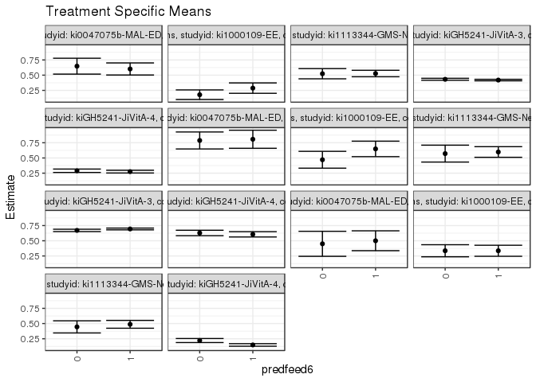

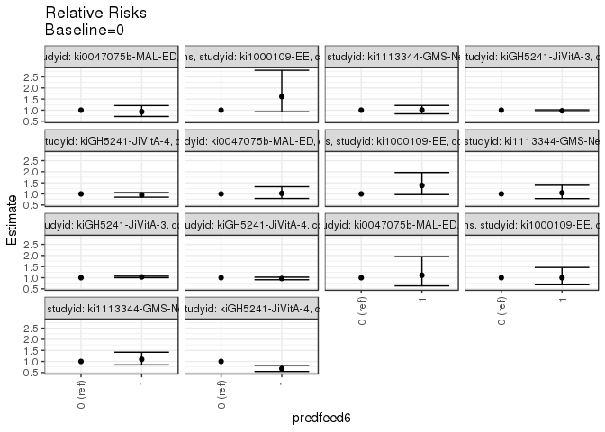

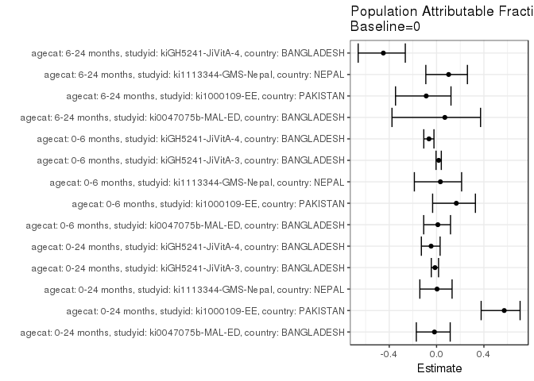

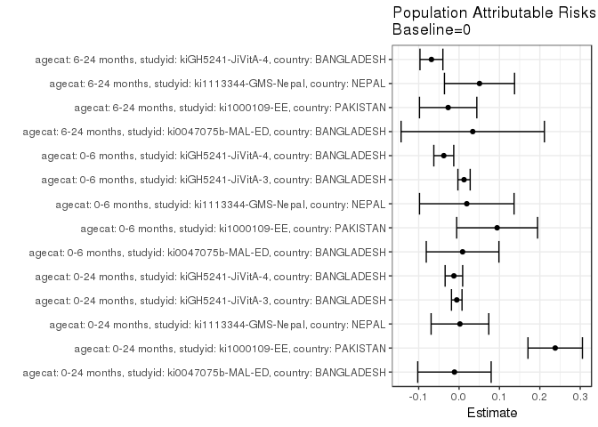

## Results Table

### Parameter: TSM

| agecat | studyid | country | intervention_level | baseline_level | estimate | ci_lower | ci_upper |
| --- | --- | --- | --- | --- | --- | --- | --- |
| 0-24 months | ki0047075b-MAL-ED | BANGLADESH | 0 | NA | 0.6477973 | 0.5173277 | 0.7782670 |
| 0-24 months | ki0047075b-MAL-ED | BANGLADESH | 1 | NA | 0.6019193 | 0.5024633 | 0.7013753 |
| 0-24 months | ki1000109-EE | PAKISTAN | 0 | NA | 0.1782939 | 0.0992147 | 0.2573731 |
| 0-24 months | ki1000109-EE | PAKISTAN | 1 | NA | 0.2871184 | 0.2019697 | 0.3722672 |
| 0-24 months | ki1113344-GMS-Nepal | NEPAL | 0 | NA | 0.5238597 | 0.4401961 | 0.6075234 |
| 0-24 months | ki1113344-GMS-Nepal | NEPAL | 1 | NA | 0.5273107 | 0.4741797 | 0.5804417 |
| 0-24 months | kiGH5241-JiVitA-3 | BANGLADESH | 0 | NA | 0.4319547 | 0.4155532 | 0.4483561 |
| 0-24 months | kiGH5241-JiVitA-3 | BANGLADESH | 1 | NA | 0.4194683 | 0.4073227 | 0.4316139 |
| 0-24 months | kiGH5241-JiVitA-4 | BANGLADESH | 0 | NA | 0.2895084 | 0.2616066 | 0.3174102 |
| 0-24 months | kiGH5241-JiVitA-4 | BANGLADESH | 1 | NA | 0.2752712 | 0.2526788 | 0.2978637 |
| 0-6 months | ki0047075b-MAL-ED | BANGLADESH | 0 | NA | 0.7878788 | 0.6482934 | 0.9274642 |
| 0-6 months | ki0047075b-MAL-ED | BANGLADESH | 1 | NA | 0.8076923 | 0.6590088 | 0.9563759 |
| 0-6 months | ki1000109-EE | PAKISTAN | 0 | NA | 0.4705882 | 0.3324773 | 0.6086992 |
| 0-6 months | ki1000109-EE | PAKISTAN | 1 | NA | 0.6491228 | 0.5218669 | 0.7763787 |
| 0-6 months | ki1113344-GMS-Nepal | NEPAL | 0 | NA | 0.5715357 | 0.4324002 | 0.7106712 |
| 0-6 months | ki1113344-GMS-Nepal | NEPAL | 1 | NA | 0.5982663 | 0.5108446 | 0.6856879 |
| 0-6 months | kiGH5241-JiVitA-3 | BANGLADESH | 0 | NA | 0.6705336 | 0.6512507 | 0.6898165 |
| 0-6 months | kiGH5241-JiVitA-3 | BANGLADESH | 1 | NA | 0.6940317 | 0.6795029 | 0.7085606 |
| 0-6 months | kiGH5241-JiVitA-4 | BANGLADESH | 0 | NA | 0.6278832 | 0.5832298 | 0.6725366 |
| 0-6 months | kiGH5241-JiVitA-4 | BANGLADESH | 1 | NA | 0.6057278 | 0.5621744 | 0.6492812 |
| 6-24 months | ki0047075b-MAL-ED | BANGLADESH | 0 | NA | 0.4500000 | 0.2444054 | 0.6555946 |
| 6-24 months | ki0047075b-MAL-ED | BANGLADESH | 1 | NA | 0.5000000 | 0.3367001 | 0.6632999 |
| 6-24 months | ki1000109-EE | PAKISTAN | 0 | NA | 0.3357447 | 0.2364613 | 0.4350281 |
| 6-24 months | ki1000109-EE | PAKISTAN | 1 | NA | 0.3355881 | 0.2449377 | 0.4262386 |
| 6-24 months | ki1113344-GMS-Nepal | NEPAL | 0 | NA | 0.4453298 | 0.3454120 | 0.5452476 |
| 6-24 months | ki1113344-GMS-Nepal | NEPAL | 1 | NA | 0.4877707 | 0.4235063 | 0.5520351 |
| 6-24 months | kiGH5241-JiVitA-4 | BANGLADESH | 0 | NA | 0.2206694 | 0.1876603 | 0.2536786 |
| 6-24 months | kiGH5241-JiVitA-4 | BANGLADESH | 1 | NA | 0.1485382 | 0.1276991 | 0.1693772 |

### Parameter: E(Y)

| agecat | studyid | country | intervention_level | baseline_level | estimate | ci_lower | ci_upper |
| --- | --- | --- | --- | --- | --- | --- | --- |
| 0-24 months | ki0047075b-MAL-ED | BANGLADESH | NA | NA | 0.6363636 | 0.5494154 | 0.7233119 |
| 0-24 months | ki1000109-EE | PAKISTAN | NA | NA | 0.4163424 | 0.3511349 | 0.4815500 |
| 0-24 months | ki1113344-GMS-Nepal | NEPAL | NA | NA | 0.5260223 | 0.4802445 | 0.5718001 |
| 0-24 months | kiGH5241-JiVitA-3 | BANGLADESH | NA | NA | 0.4262098 | 0.4150208 | 0.4373989 |
| 0-24 months | kiGH5241-JiVitA-4 | BANGLADESH | NA | NA | 0.2766885 | 0.2556490 | 0.2977279 |
| 0-6 months | ki0047075b-MAL-ED | BANGLADESH | NA | NA | 0.7966102 | 0.6946250 | 0.8985954 |
| 0-6 months | ki1000109-EE | PAKISTAN | NA | NA | 0.5648148 | 0.4692893 | 0.6603404 |
| 0-6 months | ki1113344-GMS-Nepal | NEPAL | NA | NA | 0.5906433 | 0.5164645 | 0.6648221 |
| 0-6 months | kiGH5241-JiVitA-3 | BANGLADESH | NA | NA | 0.6828279 | 0.6694976 | 0.6961581 |
| 0-6 months | kiGH5241-JiVitA-4 | BANGLADESH | NA | NA | 0.5900383 | 0.5478064 | 0.6322702 |
| 6-24 months | ki0047075b-MAL-ED | BANGLADESH | NA | NA | 0.4838710 | 0.3544124 | 0.6133295 |
| 6-24 months | ki1000109-EE | PAKISTAN | NA | NA | 0.3087248 | 0.2336906 | 0.3837591 |
| 6-24 months | ki1113344-GMS-Nepal | NEPAL | NA | NA | 0.4959128 | 0.4403572 | 0.5514684 |
| 6-24 months | kiGH5241-JiVitA-4 | BANGLADESH | NA | NA | 0.1522070 | 0.1331665 | 0.1712475 |

### Parameter: RR

| agecat | studyid | country | intervention_level | baseline_level | estimate | ci_lower | ci_upper |
| --- | --- | --- | --- | --- | --- | --- | --- |
| 0-24 months | ki0047075b-MAL-ED | BANGLADESH | 0 | 0 | 1.0000000 | 1.0000000 | 1.0000000 |
| 0-24 months | ki0047075b-MAL-ED | BANGLADESH | 1 | 0 | 0.9291784 | 0.7154329 | 1.2067834 |
| 0-24 months | ki1000109-EE | PAKISTAN | 0 | 0 | 1.0000000 | 1.0000000 | 1.0000000 |
| 0-24 months | ki1000109-EE | PAKISTAN | 1 | 0 | 1.6103661 | 0.9261703 | 2.8000021 |
| 0-24 months | ki1113344-GMS-Nepal | NEPAL | 0 | 0 | 1.0000000 | 1.0000000 | 1.0000000 |
| 0-24 months | ki1113344-GMS-Nepal | NEPAL | 1 | 0 | 1.0065875 | 0.8358929 | 1.2121390 |
| 0-24 months | kiGH5241-JiVitA-3 | BANGLADESH | 0 | 0 | 1.0000000 | 1.0000000 | 1.0000000 |
| 0-24 months | kiGH5241-JiVitA-3 | BANGLADESH | 1 | 0 | 0.9710934 | 0.9304400 | 1.0135230 |
| 0-24 months | kiGH5241-JiVitA-4 | BANGLADESH | 0 | 0 | 1.0000000 | 1.0000000 | 1.0000000 |
| 0-24 months | kiGH5241-JiVitA-4 | BANGLADESH | 1 | 0 | 0.9508229 | 0.8540534 | 1.0585570 |
| 0-6 months | ki0047075b-MAL-ED | BANGLADESH | 0 | 0 | 1.0000000 | 1.0000000 | 1.0000000 |
| 0-6 months | ki0047075b-MAL-ED | BANGLADESH | 1 | 0 | 1.0251479 | 0.7940050 | 1.3235789 |
| 0-6 months | ki1000109-EE | PAKISTAN | 0 | 0 | 1.0000000 | 1.0000000 | 1.0000000 |
| 0-6 months | ki1000109-EE | PAKISTAN | 1 | 0 | 1.3793860 | 0.9691550 | 1.9632624 |
| 0-6 months | ki1113344-GMS-Nepal | NEPAL | 0 | 0 | 1.0000000 | 1.0000000 | 1.0000000 |
| 0-6 months | ki1113344-GMS-Nepal | NEPAL | 1 | 0 | 1.0467697 | 0.7883440 | 1.3899094 |
| 0-6 months | kiGH5241-JiVitA-3 | BANGLADESH | 0 | 0 | 1.0000000 | 1.0000000 | 1.0000000 |
| 0-6 months | kiGH5241-JiVitA-3 | BANGLADESH | 1 | 0 | 1.0350439 | 1.0019452 | 1.0692360 |
| 0-6 months | kiGH5241-JiVitA-4 | BANGLADESH | 0 | 0 | 1.0000000 | 1.0000000 | 1.0000000 |
| 0-6 months | kiGH5241-JiVitA-4 | BANGLADESH | 1 | 0 | 0.9647141 | 0.9090424 | 1.0237952 |
| 6-24 months | ki0047075b-MAL-ED | BANGLADESH | 0 | 0 | 1.0000000 | 1.0000000 | 1.0000000 |
| 6-24 months | ki0047075b-MAL-ED | BANGLADESH | 1 | 0 | 1.1111111 | 0.6335362 | 1.9486934 |
| 6-24 months | ki1000109-EE | PAKISTAN | 0 | 0 | 1.0000000 | 1.0000000 | 1.0000000 |
| 6-24 months | ki1000109-EE | PAKISTAN | 1 | 0 | 0.9995336 | 0.6840430 | 1.4605331 |
| 6-24 months | ki1113344-GMS-Nepal | NEPAL | 0 | 0 | 1.0000000 | 1.0000000 | 1.0000000 |
| 6-24 months | ki1113344-GMS-Nepal | NEPAL | 1 | 0 | 1.0953023 | 0.8461345 | 1.4178446 |
| 6-24 months | kiGH5241-JiVitA-4 | BANGLADESH | 0 | 0 | 1.0000000 | 1.0000000 | 1.0000000 |
| 6-24 months | kiGH5241-JiVitA-4 | BANGLADESH | 1 | 0 | 0.6731252 | 0.5482970 | 0.8263725 |

### Parameter: PAR

| agecat | studyid | country | intervention_level | baseline_level | estimate | ci_lower | ci_upper |
| --- | --- | --- | --- | --- | --- | --- | --- |
| 0-24 months | ki0047075b-MAL-ED | BANGLADESH | 0 | NA | -0.0114337 | -0.1023280 | 0.0794606 |
| 0-24 months | ki1000109-EE | PAKISTAN | 0 | NA | 0.2380485 | 0.1706390 | 0.3054580 |
| 0-24 months | ki1113344-GMS-Nepal | NEPAL | 0 | NA | 0.0021626 | -0.0692630 | 0.0735882 |
| 0-24 months | kiGH5241-JiVitA-3 | BANGLADESH | 0 | NA | -0.0057448 | -0.0187966 | 0.0073070 |
| 0-24 months | kiGH5241-JiVitA-4 | BANGLADESH | 0 | NA | -0.0128199 | -0.0345275 | 0.0088876 |
| 0-6 months | ki0047075b-MAL-ED | BANGLADESH | 0 | NA | 0.0087314 | -0.0812361 | 0.0986989 |
| 0-6 months | ki1000109-EE | PAKISTAN | 0 | NA | 0.0942266 | -0.0059107 | 0.1943639 |
| 0-6 months | ki1113344-GMS-Nepal | NEPAL | 0 | NA | 0.0191075 | -0.0979466 | 0.1361617 |
| 0-6 months | kiGH5241-JiVitA-3 | BANGLADESH | 0 | NA | 0.0122942 | -0.0029115 | 0.0275000 |
| 0-6 months | kiGH5241-JiVitA-4 | BANGLADESH | 0 | NA | -0.0378449 | -0.0625153 | -0.0131746 |
| 6-24 months | ki0047075b-MAL-ED | BANGLADESH | 0 | NA | 0.0338710 | -0.1435771 | 0.2113190 |
| 6-24 months | ki1000109-EE | PAKISTAN | 0 | NA | -0.0270199 | -0.0980199 | 0.0439802 |
| 6-24 months | ki1113344-GMS-Nepal | NEPAL | 0 | NA | 0.0505830 | -0.0362214 | 0.1373875 |
| 6-24 months | kiGH5241-JiVitA-4 | BANGLADESH | 0 | NA | -0.0684624 | -0.0968302 | -0.0400947 |

### Parameter: PAF

| agecat | studyid | country | intervention_level | baseline_level | estimate | ci_lower | ci_upper |
| --- | --- | --- | --- | --- | --- | --- | --- |
| 0-24 months | ki0047075b-MAL-ED | BANGLADESH | 0 | NA | -0.0179673 | -0.1711171 | 0.1151548 |
| 0-24 months | ki1000109-EE | PAKISTAN | 0 | NA | 0.5717614 | 0.3766537 | 0.7058003 |
| 0-24 months | ki1113344-GMS-Nepal | NEPAL | 0 | NA | 0.0041112 | -0.1413536 | 0.1310365 |
| 0-24 months | kiGH5241-JiVitA-3 | BANGLADESH | 0 | NA | -0.0134788 | -0.0446043 | 0.0167192 |
| 0-24 months | kiGH5241-JiVitA-4 | BANGLADESH | 0 | NA | -0.0463335 | -0.1284505 | 0.0298078 |
| 0-6 months | ki0047075b-MAL-ED | BANGLADESH | 0 | NA | 0.0109607 | -0.1087726 | 0.1177643 |
| 0-6 months | ki1000109-EE | PAKISTAN | 0 | NA | 0.1668274 | -0.0333632 | 0.3282356 |
| 0-6 months | ki1113344-GMS-Nepal | NEPAL | 0 | NA | 0.0323504 | -0.1876796 | 0.2116176 |
| 0-6 months | kiGH5241-JiVitA-3 | BANGLADESH | 0 | NA | 0.0180049 | -0.0044882 | 0.0399943 |
| 0-6 months | kiGH5241-JiVitA-4 | BANGLADESH | 0 | NA | -0.0641398 | -0.1079433 | -0.0220681 |
| 6-24 months | ki0047075b-MAL-ED | BANGLADESH | 0 | NA | 0.0700000 | -0.3766411 | 0.3717317 |
| 6-24 months | ki1000109-EE | PAKISTAN | 0 | NA | -0.0875209 | -0.3468337 | 0.1218651 |
| 6-24 months | ki1113344-GMS-Nepal | NEPAL | 0 | NA | 0.1019999 | -0.0907985 | 0.2607211 |
| 6-24 months | kiGH5241-JiVitA-4 | BANGLADESH | 0 | NA | -0.4497981 | -0.6625518 | -0.2642701 |